# Employment Opportunities Predictor, Place-level

Author

JP Walsh

Published

January 31, 2024

*Program for the creation of the Employment Opportunities Upward Mobility Predictor at the place-level*

ACS Code: Initially written by Tina Chelidze and updated by JP Walsh 2022-2023.

Primary data derived from the IPUMS API.

Based on processes developed by Paul Johnson and Kevin Werner in SAS.

- Housekeeping
- Read Data
- Clean Data
- Merge Crosswalk
- Setup Survey Design
- Create Employment Metric
- Evaluate Results
- Export

## Housekeeping

Read in packages for use. If you do not have an IPUMS API key you will need to make one via the [IPUMS website](https://www.ipums.org/).

```r
library(tidyverse)
library(Hmisc)
library(ipumsr)
library(reactable)
library(srvyr)
library(scales)

options(scipen = 999)

#set_ipums_api_key("Your KEY", save = TRUE)
source(here::here("functions", "API", "extract_ipums.R"))
```

## Read Data

Read in the ACS extracts using the extract_ipums function. Make sure to change the survey list to reflect what years you want to include in the data. Currently we are including three years of 1-year data (2018a, 2021a and 2022a) and two years of 5-year data (2018c and 2021c). 5-year 2022 data will be added pending its release.

```r
acs <- extract_ipums(
  extract_name = "umf_data_18_22",
  extract_description = "Microdata pull for Mobility Metric Predictors. American Community Survey, years 2018, 2019 and 2022 (1 and 5-year).",
  survey = list("us2018a", "us2021a", "us2022a", "us2018c", "us2021c")
)
```

Look at the distribution of ACS survey samples in the data. The number of different samples should align with the number of surveys selected in the extract ipums function.

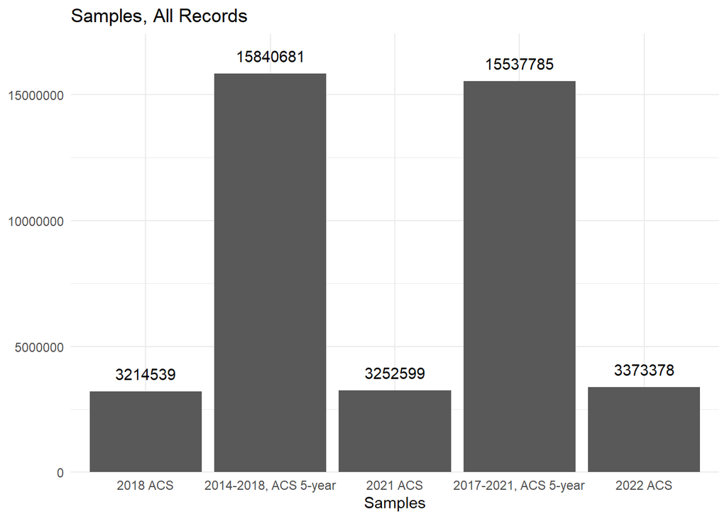

```r
acs %>%
  count(sample) %>%
  ggplot(mapping = aes(x = sample, y = n)) +
  geom_col() +
  theme_minimal() +
  ggtitle("Samples, All Records") +
 geom_text(mapping = aes(label = n), vjust = -1) +
  scale_y_continuous(expand = expansion(mult = c(0, 0.1))) +
  labs(x = "Samples",
       y = NULL)
```

Read in the PUMA to place crosswalk file. This file is created by the program generate_puma_place_crosswalks.rmd in the geographic-crosswalks folder.

```r
puma_place_crosswalk <- read_csv(here::here("geographic-crosswalks", "data", "crosswalk_puma_to_place.csv"))
```

Crate a version of the crosswalk with just the place-level values of data quality variables for each crosswalk period.

```r
place_puma <- puma_place_crosswalk %>%
  group_by(crosswalk_period, statefip, place) %>%
  summarise(geographic_allocation_quality = mean(geographic_allocation_quality)) %>%
  ungroup()
```

## Clean Data

Missing data is reported in a variety of ways by IPUMS data - listed below:

Age: No missing values reported in variable description. Empstat: N/As reported as “0”. Vacancy is reported as “0”.

There is a large share of records reported as “0” for empstat. The distribution of age looks reasonable (no bunching or extreme outliers). Note there are no vacancy results by default of the structure of census data read in.

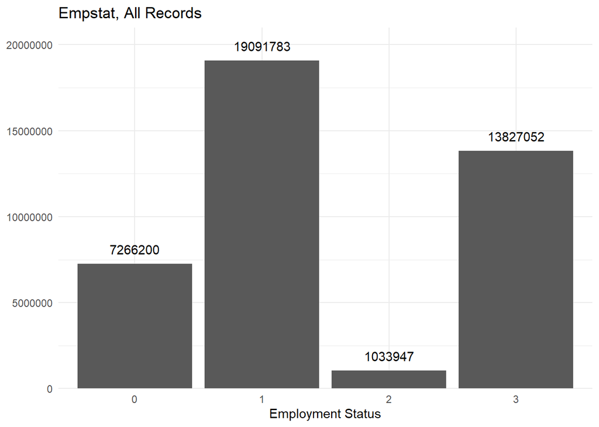

```r
acs %>%
  count(empstat) %>%
  ggplot(mapping = aes(x = factor(empstat), y = n)) +
  geom_col() +
  theme_minimal() +
  ggtitle("Empstat, All Records") +
 geom_text(mapping = aes(label = n), vjust = -1) +
  scale_y_continuous(expand = expansion(mult = c(0, 0.1))) +
  labs(x = "Employment Status",
       y = NULL)
```

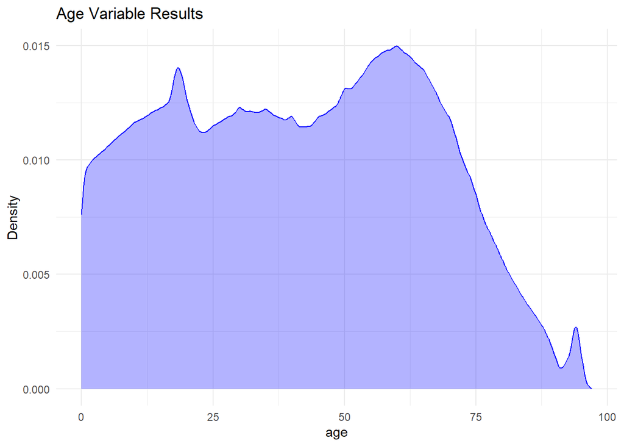

```r
acs %>%
  ggplot(aes(x = age)) +
  geom_density(color = "blue", fill = alpha("blue", 0.3)) +
  theme_minimal() +
  ggtitle("Age Variable Results") +
  ylab("Density")
```

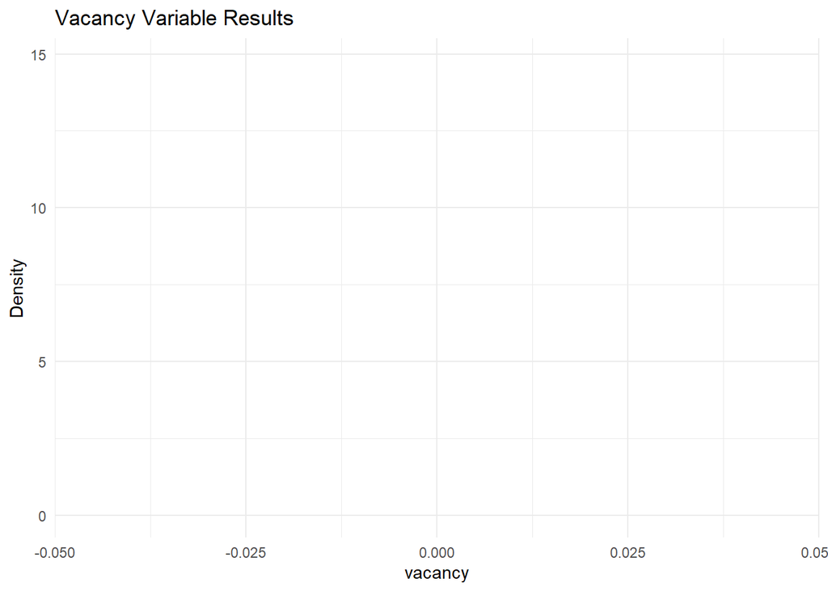

```r
acs %>%
  ggplot(aes(x = vacancy)) +
  geom_density(color = "blue", fill = alpha("blue", 0.3)) +
  theme_minimal() +
  ggtitle("Vacancy Variable Results") +
  ylab("Density")
```

Turn the missing/“not in universe” value from the empstat variable into NAs.

```r
acs_clean <- acs %>%
  mutate(empstat = ifelse(empstat == 0, NA_integer_,
                          empstat)
  )
```

Look at the distribution of empstat after adjustment for NAs. There should be no more records with the value “0”.

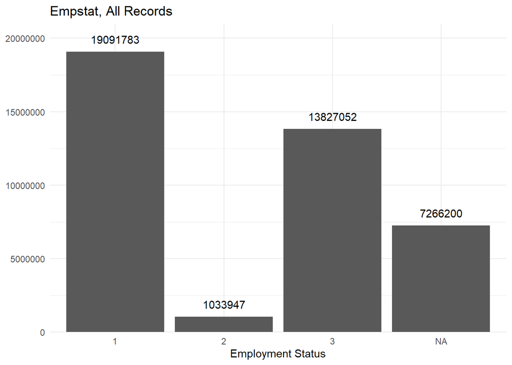

```r
acs_clean %>%
  count(empstat) %>%
  ggplot(mapping = aes(x = factor(empstat), y = n)) +
  geom_col() +
  theme_minimal() +
  ggtitle("Empstat, All Records") +
 geom_text(mapping = aes(label = n), vjust = -1) +
  scale_y_continuous(expand = expansion(mult = c(0, 0.1))) +
  labs(x = "Employment Status",
       y = NULL)
```

Filter for group quarters (GQ), we want to keep only households including additional households under updated definitions.

```r
acs_clean %>%
  group_by(gq) %>%
  count()
```

```
# A tibble: 5 x 2
# Groups:   gq [5]
  gq                                                 n
  <fct>                                          <int>
1 Households under 1970 definition            39093662
2 Additional households under 1990 definition    73638
3 Group quarters--Institutions                  977950
4 Other group quarters                         1063725
5 Additional households under 2000 definition    10007
```

```r
acs_clean <- acs_clean %>%
  filter(gq %in% c("Households under 1970 definition",
                   "Additional households under 1990 definition",
                   "Additional households under 2000 definition"))
```

Check that group quarters fall only into household categories.

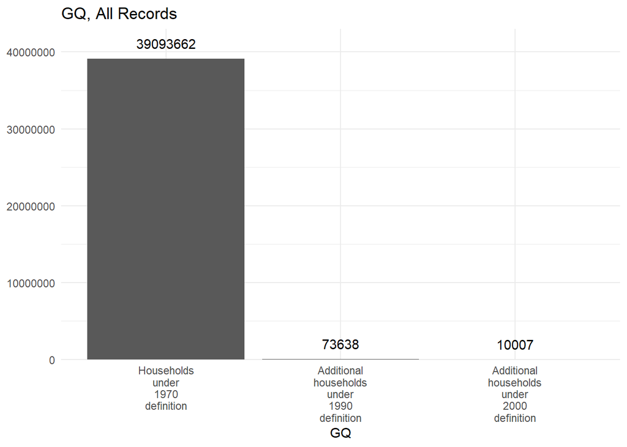

```r
acs_clean %>%
  count(gq) %>%
  ggplot(mapping = aes(x = gq, y = n)) +
  geom_col() +
  theme_minimal() +
  ggtitle("GQ, All Records") +
 geom_text(mapping = aes(label = n), vjust = -1) +
  scale_y_continuous(expand = expansion(mult = c(0, 0.1))) +
  labs(x = "GQ",
       y = NULL)+
  scale_x_discrete(labels = label_wrap(10))
```

### Create race variable

Evaluate the values in the RACE and HISPAN variables.

- IPUMS documented values for RACE:
  - 1 White
  - 2 Black/African American/Negro
  - 3 American Indian or Alaska Native
  - 4 Chinese
  - 5 Japanese
  - 6 Other Asian or Pacific Islander
  - 7 Other race
  - 8 Two major races
  - 9 Three or more major races
- IPUMS documented values for HISPAN:
  - 0 Not Hispanic
  - 1 Mexican
  - 2 Puerto Rican
  - 3 Cuban
  - 4 Other
  - 9 Not Reported

Look at the distribution of values for the race and hispan variables.

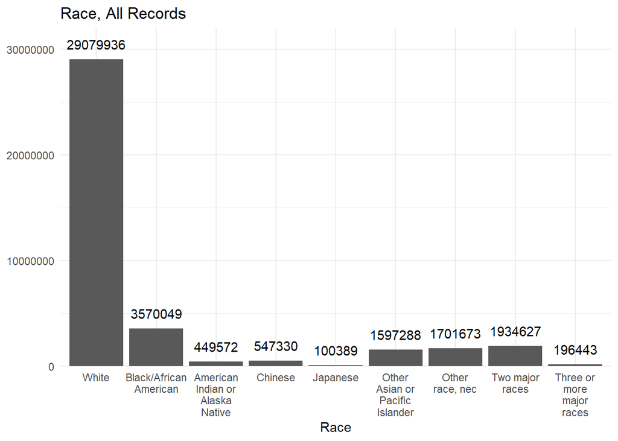

```r
acs_clean %>%
  count(race) %>%
  ggplot(mapping = aes(x = race, y = n)) +
  geom_col() +
  theme_minimal() +
  ggtitle("Race, All Records") +
 geom_text(mapping = aes(label = n), vjust = -1) +
  scale_y_continuous(expand = expansion(mult = c(0, 0.1))) +
  labs(x = "Race",
       y = NULL)+
  scale_x_discrete(labels = label_wrap(10))
```

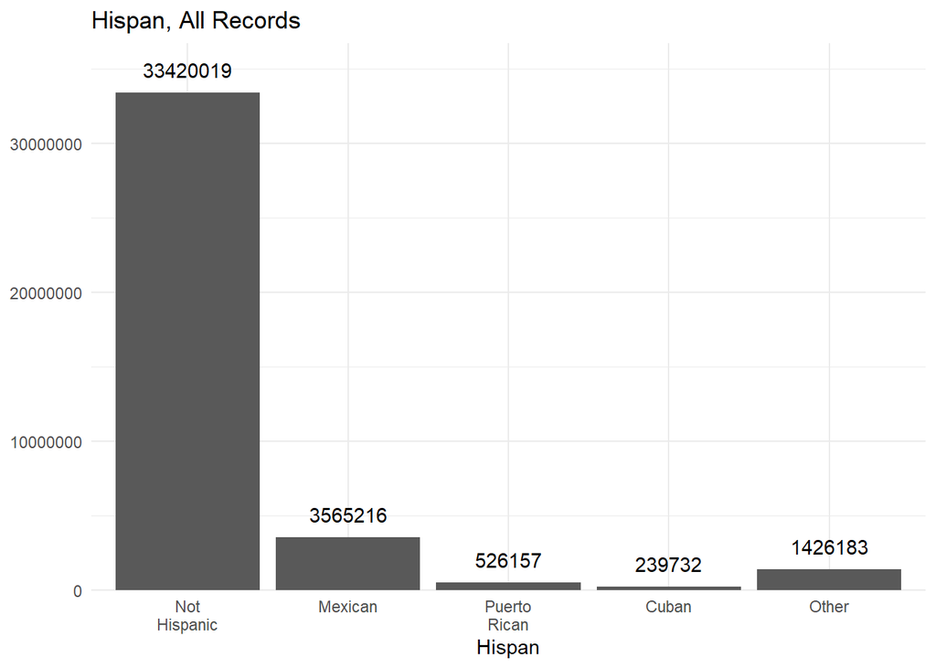

```r
acs_clean %>%
  count(hispan) %>%
  ggplot(mapping = aes(x = hispan, y = n)) +
  geom_col() +
  theme_minimal() +
  ggtitle("Hispan, All Records") +
 geom_text(mapping = aes(label = n), vjust = -1) +
  scale_y_continuous(expand = expansion(mult = c(0, 0.1))) +
  labs(x = "Hispan",
       y = NULL)+
  scale_x_discrete(labels = label_wrap(10))
```

Create the race/ethnicity variable. For race/ethnicity categories that are not coded as Hispanic, Hispan must be equal to “Not Hispanic”.

Rename the values from number category to race label: +Race is Black/African American and Hispan is Not Hispanic = “Black, Non-Hispanic” +Hispan is not equal to Not Hispanic = “Hispanic” +Race is not Black or White and Hispan is Not Hispanic = “Other Races and Ethnicities” +Race is White and Hispan is Not Hispanic = “White, Non-Hispanic”

```r
acs_clean <- acs_clean %>%
  mutate(subgroup = case_when((hispan == "Not Hispanic" & race == "White") ~ "White, Non-Hispanic",
                              (hispan == "Not Hispanic" & race == "Black/African American") ~ "Black, Non-Hispanic",
                              (hispan == "Not Hispanic" & !race %in% c("Black/African American", "White")) ~ "Other Races and Ethnicities",
                               hispan != "Not Hispanic" ~ "Hispanic"
  ))
```

Look at the subgroup distribution.

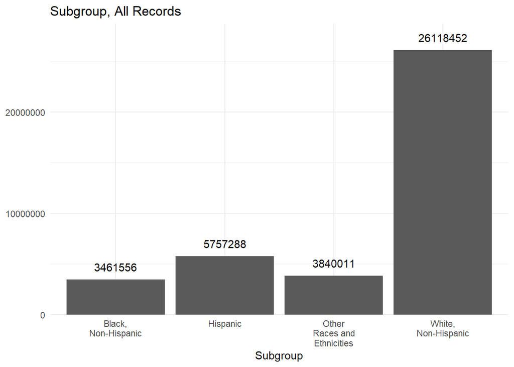

```r
acs_clean %>%
  count(subgroup) %>%
  ggplot(mapping = aes(x = factor(subgroup), y = n)) +
  geom_col() +
  theme_minimal() +
  ggtitle("Subgroup, All Records") +
 geom_text(mapping = aes(label = n), vjust = -1) +
  scale_y_continuous(expand = expansion(mult = c(0, 0.1))) +
  labs(x = "Subgroup",
       y = NULL)+
  scale_x_discrete(labels = label_wrap(10))
```

## Merge Crosswalk

Create a variable in the ACS data indicating whether the survey year is pre or post-2022. This will be used to join on the correct crosswalk information.

```r
acs_clean <- acs_clean %>%
  mutate(crosswalk_period = ifelse(year < 2022, "pre-2022", "2022"))
```

Check that the assignment worked. All years prior to 2022 should be designated “pre-2022”.

```r
acs_clean %>%
  group_by(crosswalk_period, year) %>%
  count()
```

```
# A tibble: 3 x 3
# Groups:   crosswalk_period, year [3]
  crosswalk_period  year        n
  <chr>            <int>    <int>
1 2022              2022  3192208
2 pre-2022          2018 18155811
3 pre-2022          2021 17829288
```

Join the cleaned ACS data onto the crosswalk.

```r
acs_clean <- left_join(acs_clean, puma_place_crosswalk, by=c("crosswalk_period", "statefip","puma"), relationship = "many-to-many")
```

```r
anti_join(acs_clean, puma_place_crosswalk, by=c("crosswalk_period", "statefip","puma"))
```

```
# A tibble: 20,896,420 x 28
    year multyear sample    hhwt adjust statefip puma  gq       hhincome vacancy
   <int>    <dbl> <fct>    <dbl>  <dbl> <chr>    <chr> <fct>       <dbl>   <int>
 1  2018       NA 2018 ACS    36   1.01 01       01800 Househo~    59100       0
 2  2018       NA 2018 ACS    36   1.01 01       01800 Househo~    59100       0
 3  2018       NA 2018 ACS    36   1.01 01       01800 Househo~    59100       0
 4  2018       NA 2018 ACS    36   1.01 01       01800 Househo~    59100       0
 5  2018       NA 2018 ACS    86   1.01 01       00800 Househo~    70000       0
 6  2018       NA 2018 ACS    86   1.01 01       00800 Househo~    70000       0
 7  2018       NA 2018 ACS    86   1.01 01       00800 Househo~    70000       0
 8  2018       NA 2018 ACS    86   1.01 01       00800 Househo~    70000       0
 9  2018       NA 2018 ACS    41   1.01 01       01700 Househo~    25000       0
10  2018       NA 2018 ACS    41   1.01 01       01700 Househo~    25000       0
# i 20,896,410 more rows
# i 18 more variables: pernum <dbl>, perwt <dbl>, age <int>, race <fct>,
#   hispan <fct>, empstat <int>, subgroup <chr>, crosswalk_period <chr>,
#   place <chr>, state_name <chr>, place_name <chr>, population <dbl>,
#   afact <dbl>, afact2 <dbl>, products <dbl>, sum_products <dbl>,
#   place_pop <dbl>, geographic_allocation_quality <dbl>
```

Drop any observations with NA for afact (i.e. there is no place of interest overlapping this PUMA).

```r
acs_clean <- acs_clean %>%
  drop_na(afact)
```

Also filter out cases where AFACT is equal to zero. These cases will not be counted in the metric calculation.

```r
acs_clean <- acs_clean %>%
  filter(afact > 0)
```

Adjust the person weight to account for PUMA-to-place mapping (those where the PUMA is not entirely inside the place).

```r
acs_clean <- acs_clean %>%
  mutate(perwt = perwt*afact)
```

Create a binary variable to distinguish between 1 and 5 year ACS data sets. 5-year samples include the term “5-year”.

```r
acs_clean <- acs_clean %>%
  mutate(sample_structure = ifelse(str_detect(sample, "5-year"), "5year", "1year"))
```

Isolate the data to 25-54 year-olds. This is the age-range included in the employment calculation.

```r
acs_clean <- acs_clean %>%
  filter(age >= 25 & age <= 54)
```

Create a binary employed variable indicating employed or not-employed. IPUMS data codes “Employed” as equal to 1.

```r
acs_clean <- acs_clean %>%
  mutate(employed = ifelse(empstat == 1, 1, 0))
```

Check how many records, if any, have NA reported for empstat after filtering (this should be zero).

```r
acs_clean %>%
  filter(is.na(empstat)) %>%
  group_by(pernum) %>%
  count()
```

```
# A tibble: 0 x 2
# Groups:   pernum [0]
# i 2 variables: pernum <dbl>, n <int>
```

Confirm there are no vacant properties included in the data.

```r
acs_clean %>%
  filter(is.na(vacancy)) %>%
  group_by(pernum) %>%
  count()
```

```
# A tibble: 0 x 2
# Groups:   pernum [0]
# i 2 variables: pernum <dbl>, n <int>
```

## Setup Survey Design

Set up the survey design using instructions from IPUMS. To speed up the srvyr calculation we combine the data by grouping the employed variable and summing the perwt variable - this limits the number of rows that have to go through the survey_mean function.

```r
acs_survey_all <- acs_clean %>%
  filter(sample_structure == "1year") %>%
  group_by(year, crosswalk_period, statefip, place, employed) %>%
  summarise(perwt = sum(perwt)) %>%
  as_survey_design(weights = perwt) %>%
  ungroup()

acs_survey_subgroups <- acs_clean %>%
  filter(sample_structure == "5year") %>%
  group_by(year, crosswalk_period, statefip, place, employed, subgroup) %>%
  summarise(perwt = sum(perwt)) %>%
  as_survey_design(weights = perwt) %>%
  ungroup()
```

## Create employment metric

Create the employment metric.

Objective: get the percent of individuals between the ages 25 and 54 that are employed in every place.

Aggregation should be weighted by PERWT (this is a person level statistic).

Check national employment ratio. Compute the ratio (share employed) for 2018, 2021 and 2022 nationally and show results.

```r
acs_survey_all %>%
  group_by(year) %>%
  summarise(
    share_employed = survey_mean(employed),
    count = unweighted(n())
  ) %>%
  ungroup() %>%
  reactable()
```

| year | share_employed | share_employed_se | count |
| --- | --- | --- | --- |
| 2018 | 0.802061340045896 | 0.025615711066346 | 970 |
| 2021 | 0.785174186093115 | 0.0276063984266475 | 970 |
| 2022 | 0.814633764692033 | 0.0238318493781961 | 972 |

### All

Create share employed for all individuals at the place-level (1-year data) using the survey_mean function.

```r
metrics_employment_all <- acs_survey_all %>%
  group_by(year, crosswalk_period, statefip, place) %>%
  summarise(
    share_employed = survey_mean(employed, vartype = NULL)
  ) %>%
  ungroup()
```

Sort by year, state and place.

```r
metrics_employment_all <- metrics_employment_all %>%
  arrange(year, statefip, place)
```

*Create an indicator for data quality and suppression*

Calculate the effective sample count for each place, defined as the sum of the afact variable. This is used to create a cutoff for data quality based on the actual number of survey records being used in the calculation.

```r
effective_sample <- acs_clean %>%
  filter(sample_structure == "1year") %>%
  group_by(year, crosswalk_period, statefip, place) %>%
  summarise(effective_sample = sum(afact)) %>%
  ungroup()
```

Merge the data quality flags from place_puma and effective sample onto the employment metric to create the final data quality metric. This metric is based on both size of place and the number of samples for that place.

```r
metrics_employment_all <- left_join(metrics_employment_all, place_puma, by=c("crosswalk_period", "statefip","place"))

metrics_employment_all <- left_join(metrics_employment_all, effective_sample, by=c("year", "crosswalk_period", "statefip","place"))
```

Tabulate effective sample counts for each place, defined as the sum of the afact for all records in that place. Look at the distribution of places by potential cutoffs (30, 100, 300). This is to measure data quality for each place based on the number of records reported. In the 1-year data for all there are no cases of a place with less than 100 observations for 2018, 2021 and 2022.

```r
reactable_data <- metrics_employment_all %>%
  mutate(
    effective_sample_cutoffs = case_when(
      effective_sample < 30 ~ "Less than 30",
      effective_sample >= 30 &
        effective_sample <= 100 ~ "Over 30 but 100 or less",
      effective_sample > 100 &
        effective_sample <= 300 ~ "Over 100 but 300 or less",
      TRUE ~ "Greater than 300"
    ),
    effective_sample_cutoffs = factor(
      effective_sample_cutoffs,
      levels = c(
        "Less than 30",
        "Over 30 but 100 or less",
        "Over 100 but 300 or less",
        "Greater than 300"
      )
    )
  )

# Get suppression factor for each year of data
suppression_factor <- reactable_data %>%
  group_by(year) %>%
  summarize(yearly_total = n()) %>%
  select(year, yearly_total)

# Create reactable for further examination
reactable_data %>%
  left_join(suppression_factor, by="year") %>%
  group_by(year,effective_sample_cutoffs) %>%
  summarize(n = n(), suppression_share = n()/unique(yearly_total)) %>% # yearly value has one unique value per year
  reactable()
```

| year | effective_sample_cutoffs | n | suppression_share |
| --- | --- | --- | --- |
| 2018 | Over 100 but 300 or less | 132 | 0.272164948453608 |
| 2018 | Greater than 300 | 353 | 0.727835051546392 |
| 2021 | Over 100 but 300 or less | 126 | 0.25979381443299 |
| 2021 | Greater than 300 | 359 | 0.74020618556701 |
| 2022 | Over 100 but 300 or less | 112 | 0.230452674897119 |
| 2022 | Greater than 300 | 374 | 0.769547325102881 |

Generate the quality variable for each place.

```r
metrics_employment_all <- metrics_employment_all %>%
  mutate(effective_sample_flag = ifelse(effective_sample < 100, 1, 0),
         share_employed_quality = case_when(effective_sample_flag==0 & geographic_allocation_quality==1 ~ 1,
                                     effective_sample_flag==0 & geographic_allocation_quality==2 ~ 2,
                                     effective_sample_flag==0 & geographic_allocation_quality==3 ~ 3,
                                     effective_sample_flag==1 ~ 3)
  )
```

We do not want to show values that are calculated from less than 30 samples in the data. These points will be suppressed and shown as missing or NA. Suppress the results for values generated from less than 30 samples.

```r
metrics_employment_all <- metrics_employment_all %>%
  mutate_at(c("share_employed"), ~if_else(effective_sample < 30, NA_integer_, .))
```

Keep only relevant variables.

```r
metrics_employment_all <- metrics_employment_all %>%
  select(year,
         statefip,
         place,
         share_employed,
         share_employed_quality)
```

### Subgroup

Create share employed by race/ethnicity at the place-level (5-year data).

```r
metrics_employment_subgroup <- acs_survey_subgroups %>%
  group_by(year, crosswalk_period, statefip, place, subgroup) %>%
 summarise(
    share_employed = survey_mean(employed, vartype = NULL)
  ) %>%
  ungroup() %>%
  mutate(subgroup_type = "race-ethnicity")
```

Create the share employed measure for all values in the 5-year data (non-subgroup). This value will be merged onto the subgroup data.

```r
metrics_employment_subgroup_all <- acs_survey_subgroups %>%
  group_by(year, crosswalk_period, statefip, place) %>%
  summarise(
   share_employed = survey_mean(employed, vartype = NULL)
  ) %>%
  ungroup() %>%
  mutate(subgroup_type = "all",
         subgroup = "All")
```

Append the “All” version of the 5-year data with the subgroup results.

```r
metrics_employment_sub <- bind_rows(metrics_employment_subgroup, metrics_employment_subgroup_all)
```

Sort by year, state and place.

```r
metrics_employment_sub <- metrics_employment_sub %>%
  arrange(year, statefip, place)
```

*Create an indicator for data quality and suppression*

Calculate the effective sample count for each subgroup in all places as well as for all samples in every place in the 5-year data.

```r
effective_sample_sub_all <- acs_clean %>%
  filter(sample_structure == "5year") %>%
  group_by(year, crosswalk_period, statefip, place) %>%
  summarise(effective_sample = sum(afact)) %>%
  mutate(subgroup_type = "all",
         subgroup = "All")

effective_sample_sub <- acs_clean %>%
  filter(sample_structure == "5year") %>%
  group_by(year, crosswalk_period, statefip, place, subgroup) %>%
  summarise(effective_sample = sum(afact)) %>%
  mutate(subgroup_type = "race-ethnicity") %>%
  bind_rows(effective_sample_sub_all) %>%
  ungroup()
```

Merge the data quality flags and create the final data quality metric based on both size and geographic allocation.

```r
metrics_employment_sub <- left_join(metrics_employment_sub, place_puma, by=c("crosswalk_period", "statefip","place"))

metrics_employment_sub <- left_join(metrics_employment_sub, effective_sample_sub, by=c("year", "crosswalk_period", "statefip","place", "subgroup_type", "subgroup"))
```

Tabulate effective sample counts for each place by sugroup, defined as the sum of the afact for all records in that place. Look at the distribution of places by potential cutoffs (30, 100, 300). This is to measure data quality for each place based on the number of records reported.

```r
reactable_data <- metrics_employment_sub %>%
  mutate(
    effective_sample_cutoffs = case_when(
      effective_sample < 30 ~ "Less than 30",
      effective_sample >= 30 &
        effective_sample <= 100 ~ "Over 30 but 100 or less",
      effective_sample > 100 &
        effective_sample <= 300 ~ "Over 100 but 300 or less",
      TRUE ~ "Greater than 300"
    ),
    effective_sample_cutoffs = factor(
      effective_sample_cutoffs,
      levels = c(
        "Less than 30",
        "Over 30 but 100 or less",
        "Over 100 but 300 or less",
        "Greater than 300"
      )
    )
  )

# Create reactable for further examination using suppression factor defined earlier
reactable_data %>%
  left_join(suppression_factor, by="year") %>%
  group_by(year,subgroup,effective_sample_cutoffs) %>%
  summarize(n = n(), suppression_share = n()/unique(yearly_total)) %>% # yearly value has one unique value per year
  reactable()
```

| year | subgroup | effective_sample_cutoffs | n | suppression_share |
| --- | --- | --- | --- | --- |
| 2018 | All | Greater than 300 | 485 | 1 |
| 2018 | Black, Non-Hispanic | Less than 30 | 87 | 0.179381443298969 |
| 2018 | Black, Non-Hispanic | Over 30 but 100 or less | 126 | 0.25979381443299 |
| 2018 | Black, Non-Hispanic | Over 100 but 300 or less | 119 | 0.245360824742268 |
| 2018 | Black, Non-Hispanic | Greater than 300 | 152 | 0.31340206185567 |
| 2018 | Hispanic | Less than 30 | 8 | 0.0164948453608247 |
| 2018 | Hispanic | Over 30 but 100 or less | 77 | 0.158762886597938 |
| 2018 | Hispanic | Over 100 but 300 or less | 127 | 0.261855670103093 |
| 2018 | Hispanic | Greater than 300 | 273 | 0.562886597938144 |
| 2018 | Other Races and Ethnicities | Less than 30 | 11 | 0.022680412371134 |

[output cut: 24 more lines]

Generate the quality variable for each place.

```r
metrics_employment_sub <- metrics_employment_sub %>%
  mutate(effective_sample_flag = ifelse(effective_sample < 100, 1, 0),
         share_employed_quality = case_when(effective_sample_flag==0 & geographic_allocation_quality==1 ~ 1,
                                     effective_sample_flag==0 & geographic_allocation_quality==2 ~ 2,
                                     effective_sample_flag==0 & geographic_allocation_quality==3 ~ 3,
                                     effective_sample_flag==1 ~ 3)
  )
```

We do not want to show values that are calculated from less than 30 samples in the data. These points will be suppressed and shown as missing or NA. Suppress the results for values generated from less than 30 samples.

```r
metrics_employment_sub <- metrics_employment_sub %>%
  mutate_at(c("share_employed"), ~if_else(effective_sample < 30, NA_integer_, .))
```

Keep only relevant variables.

```r
metrics_employment_sub <- metrics_employment_sub %>%
  select(year,
         statefip,
         place,
         subgroup_type,
         subgroup,
         share_employed,
         share_employed_quality)
```

### Evaluate results

Summarize the predictors for the 1-year and 5-year data.

```r
metrics_employment_all %>%
  select(share_employed:share_employed_quality) %>%
  summary()
```

```
 share_employed   share_employed_quality
 Min.   :0.5866   Min.   :1.000
 1st Qu.:0.7763   1st Qu.:1.000
 Median :0.8073   Median :2.000
 Mean   :0.8023   Mean   :1.873
 3rd Qu.:0.8344   3rd Qu.:2.000
 Max.   :0.9333   Max.   :3.000
```

```r
metrics_employment_sub %>%
  select(share_employed:share_employed_quality) %>%
  summary()
```

```
 share_employed   share_employed_quality
 Min.   :0.3360   Min.   :1.000
 1st Qu.:0.7563   1st Qu.:2.000
 Median :0.7926   Median :2.000
 Mean   :0.7857   Mean   :2.208
 3rd Qu.:0.8225   3rd Qu.:3.000
 Max.   :0.9447   Max.   :3.000
 NA's   :207
```

Look at distribution of employment share by place.

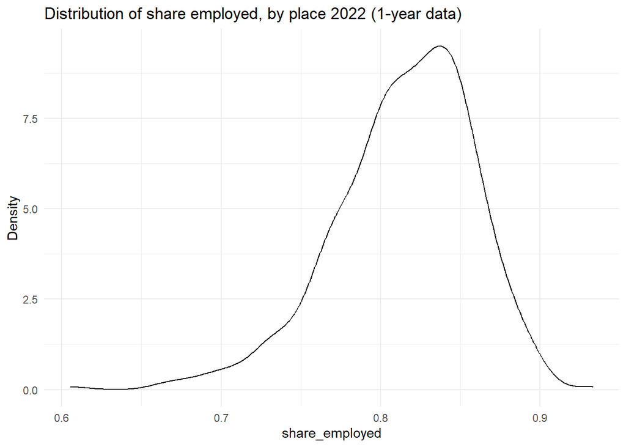

```r
metrics_employment_all %>%
  filter(year == 2022) %>%
  select(share_employed) %>%
  ggplot(aes(x = share_employed)) +
  geom_density(alpha = 0.15) +
  theme_minimal() +
  ggtitle("Distribution of share employed, by place 2022 (1-year data)") +
  ylab("Density")
```

[figure not shown]

```r
metrics_employment_sub %>%
  filter(year == 2021, subgroup == "All") %>%
  select(share_employed) %>%
  ggplot(aes(x = share_employed)) +
  geom_density(alpha = 0.15) +
  theme_minimal() +
  ggtitle("Distribution of share employed, by place 2022 (5-year data)") +
  ylab("Density")
```

Look at distribution of employment share by place by race.

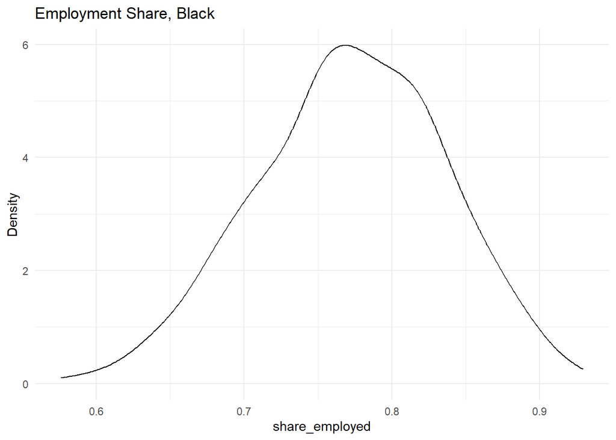

```r
metrics_employment_sub %>%
  filter(year == 2021, subgroup == "Black, Non-Hispanic") %>%
  select(place, share_employed) %>%
  ggplot(aes(x = share_employed)) +
  geom_density(alpha = 0.15) +
  theme_minimal() +
  ggtitle("Employment Share, Black") +
  ylab("Density")
```

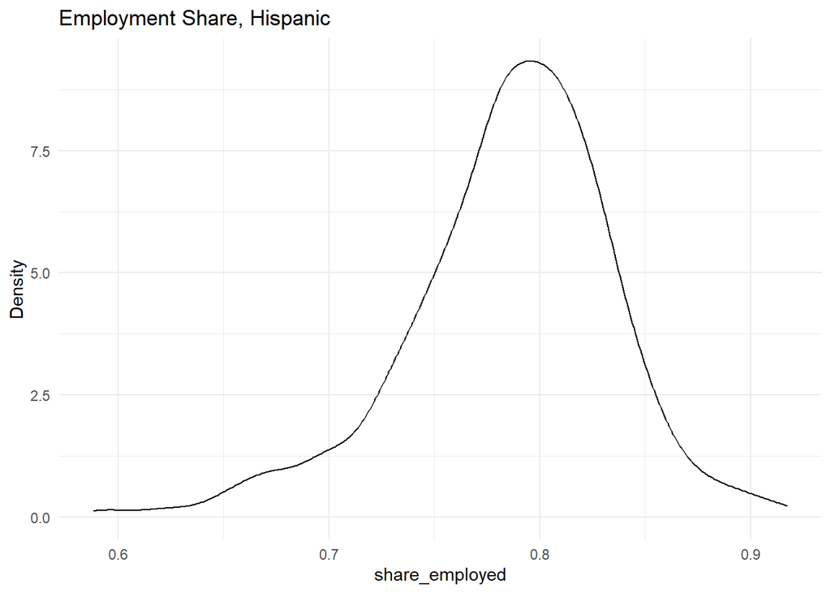

```r
metrics_employment_sub %>%
  filter(year == 2021, subgroup == "Hispanic") %>%
  select(place, share_employed) %>%
  ggplot(aes(x = share_employed)) +
  geom_density(alpha = 0.15) +
  theme_minimal() +
  ggtitle("Employment Share, Hispanic") +
  ylab("Density")
```

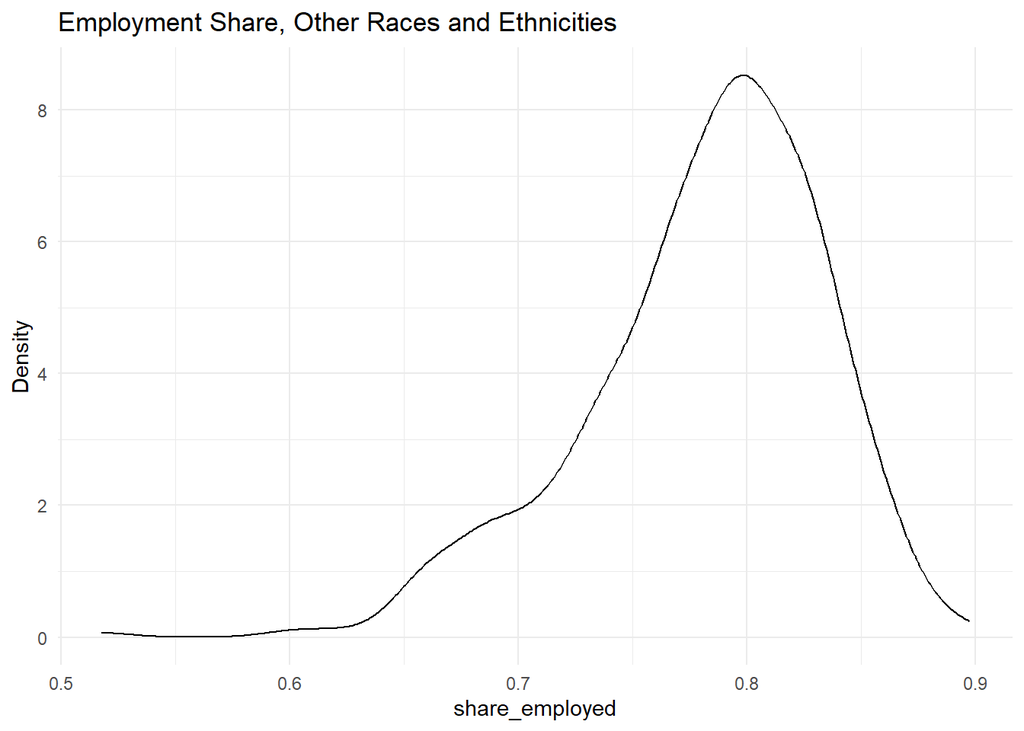

```r
metrics_employment_sub %>%
  filter(year == 2021, subgroup == "Other Races and Ethnicities") %>%
  select(place, share_employed) %>%
  ggplot(aes(x = share_employed)) +
  geom_density(alpha = 0.15) +
  theme_minimal() +
  ggtitle("Employment Share, Other Races and Ethnicities") +
  ylab("Density")
```

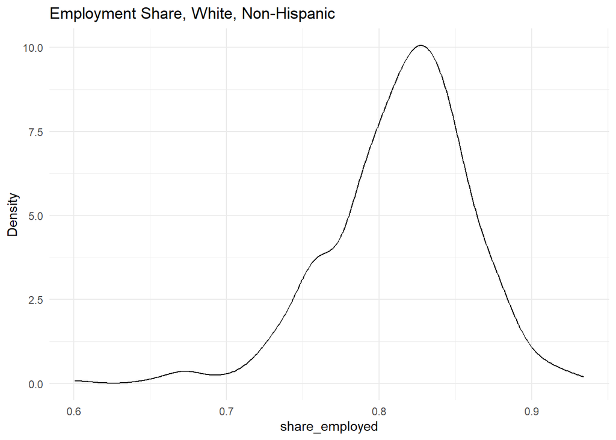

```r
metrics_employment_sub %>%
  filter(year == 2021, subgroup == "White, Non-Hispanic") %>%
  select(place, share_employed) %>%
  ggplot(aes(x = share_employed)) +
  geom_density(alpha = 0.15) +
  theme_minimal() +
  ggtitle("Employment Share, White, Non-Hispanic") +
  ylab("Density")
```

Look at the counts of the quality flag.

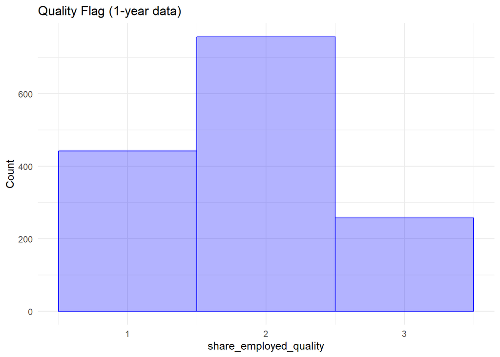

```r
metrics_employment_all %>%
  select(share_employed_quality) %>%
  ggplot(aes(x = share_employed_quality)) +
  geom_histogram(color = "blue", fill = alpha("blue", 0.3), binwidth = 1.0) +
  theme_minimal() +
  ggtitle("Quality Flag (1-year data)") +
  ylab("Count")
```

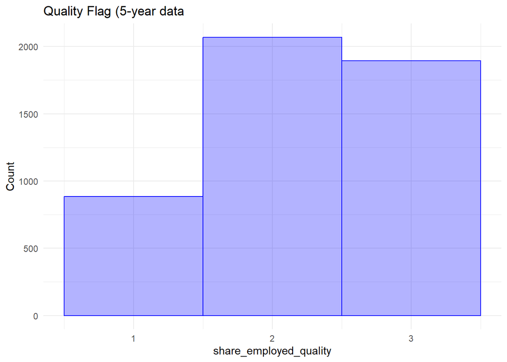

```r
metrics_employment_sub %>%
  select(share_employed_quality) %>%
  ggplot(aes(x = share_employed_quality)) +
  geom_histogram(color = "blue", fill = alpha("blue", 0.3), binwidth = 1.0) +
  theme_minimal() +
  ggtitle("Quality Flag (5-year data") +
  ylab("Count")
```

Tabulate share of data suppressed by year.

```r
metrics_employment_all %>%
  group_by(year) %>%
  filter(is.na(share_employed)) %>%
  count()
```

```
# A tibble: 0 x 2
# Groups:   year [0]
# i 2 variables: year <int>, n <int>
```

```r
metrics_employment_sub %>%
  group_by(year) %>%
  filter(is.na(share_employed)) %>%
  count()
```

```
# A tibble: 2 x 2
# Groups:   year [2]
   year     n
  <int> <int>
1  2018   107
2  2021   100
```

## Export

Rename state.

```r
metrics_employment_all <- metrics_employment_all %>%
  rename("state" = "statefip")

metrics_employment_sub <- metrics_employment_sub %>%
  rename("state" = "statefip")
```

Order the variables how we want.

```r
metrics_employment_all <- metrics_employment_all %>%
  select(year, state, place, share_employed, share_employed_quality)

metrics_employment_sub <- metrics_employment_sub %>%
  select(year, state, place, subgroup_type, subgroup, share_employed, share_employed_quality)
```

Export as CSV

```r
write_csv(metrics_employment_all, here::here("09_employment", "data", "final", "metrics_employment_place_all_longitudinal.csv"))
write_csv(metrics_employment_sub, here::here("09_employment", "data", "final", "metrics_employment_place_race-ethnicity_longitudinal.csv"))
```